# Statistical inference with the GSS data

Author: TOSHAN MAJUMDAR

Time: February, 2019

## General Social Survey (GSS) data

### **OFFICIAL DESCRIPTION:**

The GSS gathers data on contemporary American society in order to monitor and explain trends and constants in attitudes, behaviors, and attributes. Hundreds of trends have been tracked since 1972. In addition, since the GSS adopted questions from earlier surveys, trends can be followed for up to 80 years.

The GSS contains a standard core of demographic, behavioral, and attitudinal questions, plus topics of special interest. Among the topics covered are civil liberties, crime and violence, intergroup tolerance, morality, national spending priorities, psychological well-being, social mobility, and stress and traumatic events.

Altogether the GSS is the single best source for sociological and attitudinal trend data covering the United States. It allows researchers to examine the structure and functioning of society in general as well as the role played by relevant subgroups and to compare the United States to other nations.

The GSS aims to make high-quality data easily accessible to scholars, students, policy makers, and others, with minimal cost and waiting.

SOURCE: http://gss.norc.org/About-The-GSS

### **DATA DESCRIPTION:**

The given dataset gss contans data regarding the General Social Survey survey conducted among the adult population of US citizens every 1-2 years(1972 onwards) obtained through telephonic,computerised and face to face interviews. The data within the dataset:gss is organized in such a way that each row represents the responses of an individual participant and each column represents the variables of interest related to participants such as age(age of respondent), marital(marital status of respondent), income06(total family income of respondent).

### **SAMPLING/GENERIZABILITY:**

The GSS survey covers about 97.3% of the adult, household US population and thus the results from the survey are highly generizable. The sampling stratergies for the survey have been evolving throughout the years to account for the socio-political changes in society as well as to accomodate better statistical tools for analysis with the curret sampling method being full probability sampling method (employed from the 1975 survey). Non-english native speakers were included in the gss survey from 2006 onwards.

### **CAUSALITY:**

Since the entire dataset gss.RData is gathered by an observational study, any strong associations among variables can only be considered correlations and not proof of causation. The bulk of information is also dependent upon the willingness of the participants to divulge information as well as the amount of truthfulness of the information disclosed and hence can be refuted and not completely reliable. There might also exist certain unobservable variables which could influence the values of the observed variables but have not been recorded in the dataset (confounders).

## Setup

### Load packages

```r
library(ggplot2)
library(dplyr)
library(statsr)
library(doBy)
rm(list=ls())
```

LOAD DATA

```r
load("gss.Rdata")
```

# Part 1: Data

```r
#dimensions of data: rows indicate individual cases, columns indicate variables
dim(gss)
```

```
## [1] 57061   114
```

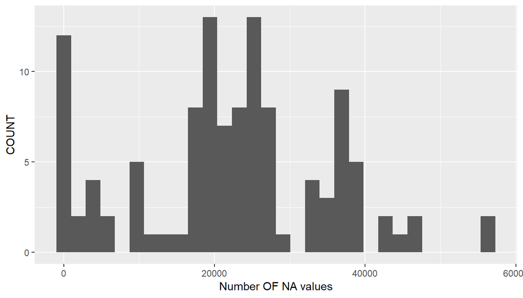

```r
#histogram of NA counts among variables in dataset:gss
column.counts <- colSums(is.na(gss),na.rm=FALSE)
ggplot(NULL, aes(x=column.counts)) + geom_histogram() +xlab("Number OF NA values")+ylab("COUNT")
```

```r
#distribution of different types of variables in dataset:gss
my.class <- sapply(gss, class)
n<-sum(my.class=="numeric")
i<-sum(my.class=="integer")
f<-sum(my.class=="factor")
cat("NUMERICAL VARIABLES:",n)
```

```
## NUMERICAL VARIABLES: 1
```

```r
cat("INTEGER VARIABLES:",i)
```

```
## INTEGER VARIABLES: 14
```

```r
cat("CATEGORICAL VARIABLES:",f)
```

```
## CATEGORICAL VARIABLES: 99
```

# Part 2: Research question

Since the current US administration has taken various legal steps to try to alter the immigration scenario of the country which has casued a debate in the general public, I wish to investigate the socio-economic conditions of US citizens vs those of non-US citizens. The following variables have been selected by me to represent the socio-economic status of the survey respondents and will be used in the inference:

1. Is there any difference between the **median income** of US citizens vs non-US citizens
2. Is there any difference between the **mean years spent in education** among US citizens vs non-US citizens

However since the gss is only an observational study, any inferences or strong assosiations among variables can only treated as correlations and not as causation since there might be confounding variables which are unobservable.

# Part 3: Exploratory data analysis

While the dataset:gss contains survey data from the years 1972-2012, I will only be doing inference on the 2012 survey data to control for factors such as change in education, income due to time as well as trying to prevent data analysis of peopele who have done the survey multiple times.

```r
# selecting income levels,US citizenship status of people in the year 2012 from dataset:gss
RQ1 <- subset(gss, year==2012 & (uscitzn=="A U.S. Citizen" | uscitzn=="Not A U.S. Citizen"), select=c(uscitzn,coninc))
RQ1 <- RQ1[complete.cases(RQ1),]
RQ1 <- RQ1 %>%
  mutate(uscitzn = ifelse(uscitzn=="A U.S. Citizen", "US citizen","Non US citizen"))

#data summary
RQ1 %>%
  group_by(uscitzn) %>%
  summarise(mean(coninc),median(coninc),sd(coninc),min(coninc),max(coninc),IQR(coninc))
```

```
## # A tibble: 2 x 7
##   uscitzn `mean(coninc)` `median(coninc)` `sd(coninc)` `min(coninc)`
##   <chr>            <dbl>            <dbl>        <dbl>         <dbl>
## 1 Non US~         42097.            24895       45021.          1532
## 2 US cit~         52648.            34470       47518.          1532
## # ... with 2 more variables: `max(coninc)` <dbl>, `IQR(coninc)` <dbl>
```

```r
# selecting education years,US citizenship status of people in the year 2012 from dataset:gss
RQ2 <- subset(gss, year==2012 & (uscitzn=="A U.S. Citizen" | uscitzn=="Not A U.S. Citizen"), select=c(uscitzn,educ))
RQ2 <- RQ2[complete.cases(RQ2),]
RQ2 <- RQ2 %>%
  mutate(uscitzn = ifelse(uscitzn=="A U.S. Citizen", "US citizen","Non US citizen"))
#unique(RQ2$uscitzn)

#data summary
RQ2 %>%
  group_by(uscitzn) %>%
  summarise(mean(educ),median(educ),sd(educ),min(educ),max(educ),IQR(educ))
```

```
## # A tibble: 2 x 7
##   uscitzn `mean(educ)` `median(educ)` `sd(educ)` `min(educ)` `max(educ)`
##   <chr>          <dbl>          <dbl>      <dbl>       <dbl>       <dbl>
## 1 Non US~         11.5             12       5.08           0          20
## 2 US cit~         13.5             14       3.96           1          20
## # ... with 1 more variable: `IQR(educ)` <dbl>
```

After storing the income and education years of respondents in separate data farmes, I try to graphically investigate the differences in their distributions and whether they look similar or different for US vs non-US citizens.

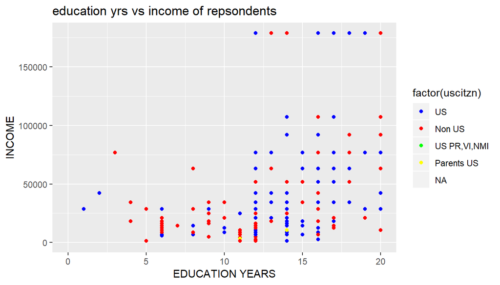

```r
# edu vs inc for both US/non US citizens
ggplot(subset(gss,year==2012),aes(x=educ,y=coninc))+geom_point(aes(colour=factor(uscitzn))) +scale_color_manual(labels = c("US", "Non US","US PR,VI,NMI","Parents US"), values = c("blue", "red","green","yellow"))+labs(title="education yrs vs income of repsondents",x="EDUCATION YEARS",y="INCOME")
```

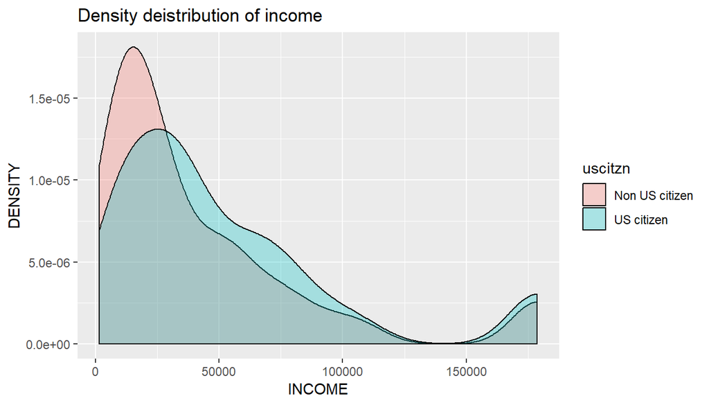

```r
#density distributions
ggplot(RQ1, aes(x=coninc, fill=uscitzn)) + geom_density(alpha=.3)+labs(title="Density deistribution of income",x="INCOME",y="DENSITY")
```

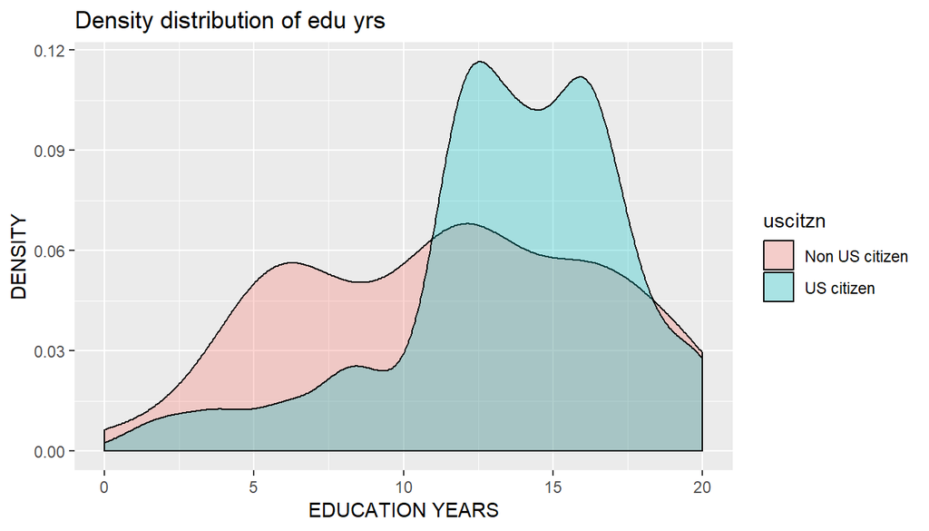

```r
ggplot(RQ2, aes(x=educ, fill=uscitzn)) + geom_density(alpha=.3)+labs(title="Density distribution of edu yrs",x="EDUCATION YEARS",y="DENSITY")
```

# Part 4: Inference

### **INFERENCE CONDITIONS**

The following are the conditions required for the inference testing which have been accounted for:

1. Independence of observations
2. Contstant variance among sample data
3. Approximate normality of sample distribution

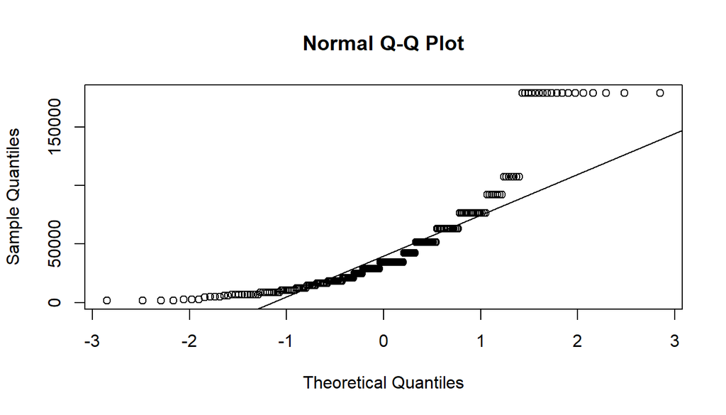

```r
# normal probability plots for education years and income
qqnorm(RQ1$coninc)
qqline(RQ1$coninc)
```

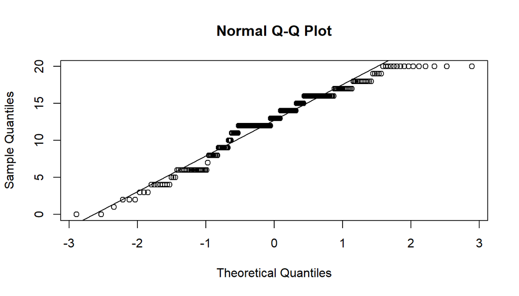

```r
qqnorm(RQ2$educ)
qqline(RQ2$educ)
```

### **INFERENCE 1**

The first hypothesis we test according to the research question is:

**Null Hypothesis (H0): Median income(US) == Median income(non-US)**

**Alternate Hypothesis (HA) : Median income(US) != Median income(non-US)**

```r
# income level equality hypothesis test among US/non US citizens
inference(y = coninc, x = as.factor(uscitzn), data =RQ1, statistic = "median", type = "ht", null = 0, alternative = "twosided", method = "simulation")
```

```
## Response variable: numerical
## Explanatory variable: categorical (2 levels)
## n_Non US citizen = 105, y_med_Non US citizen = 24895, IQR_Non US citizen = 39257
## n_US citizen = 124, y_med_US citizen = 34470, IQR_US citizen = 45481.25
## H0: mu_Non US citizen =  mu_US citizen
## HA: mu_Non US citizen != mu_US citizen
## p_value = 0.0228
```

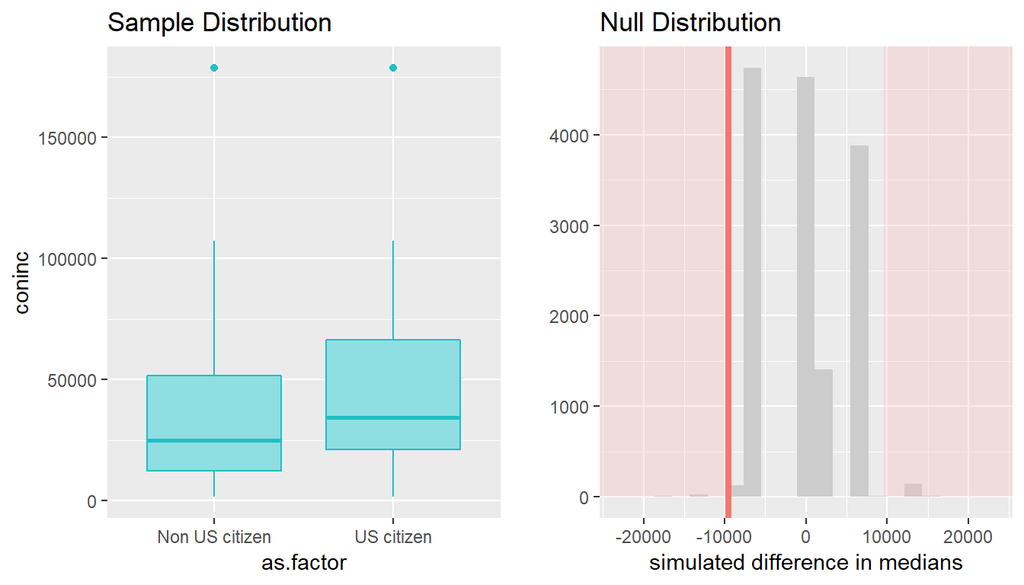

```r
#income levels difference confidence intervals
inference(y = coninc, x = as.factor(uscitzn), data =RQ1, statistic = "median", type = "ci", null = 0, alternative = "twosided", method = "simulation",boot_method="se")
```

```
## Response variable: numerical, Explanatory variable: categorical (2 levels)
## n_Non US citizen = 105, y_med_Non US citizen = 24895, IQR_Non US citizen = 39257
## n_US citizen = 124, y_med_US citizen = 34470, IQR_US citizen = 45481.25
## 95% CI (Non US citizen - US citizen): (-21205.0826 , 2055.0826)
```

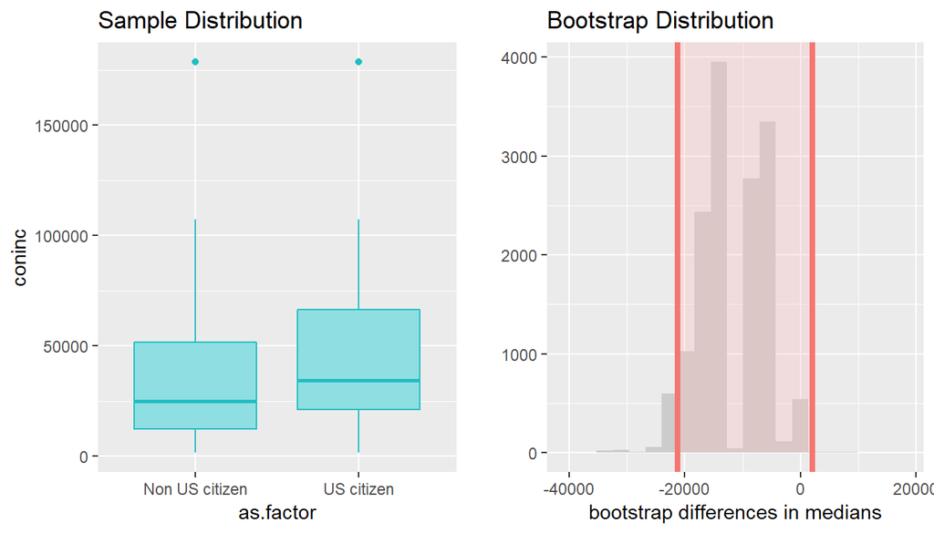

**Null Hypothesis (H0): Median income(US) !> Median income(non-US)**

**Alternate Hypothesis (HA) : Median income(US) > Median income(non-US)**

```r
# discovering higher,lower income levels difference among US/non US citizens
inference(y = coninc, x = as.factor(uscitzn), data =RQ1, statistic = "median", type = "ht", null = 0, alternative = "less", method = "simulation")
```

```
## Response variable: numerical
## Explanatory variable: categorical (2 levels)
## n_Non US citizen = 105, y_med_Non US citizen = 24895, IQR_Non US citizen = 39257
## n_US citizen = 124, y_med_US citizen = 34470, IQR_US citizen = 45481.25
## H0: mu_Non US citizen =  mu_US citizen
## HA: mu_Non US citizen < mu_US citizen
## p_value = 0.0103
```

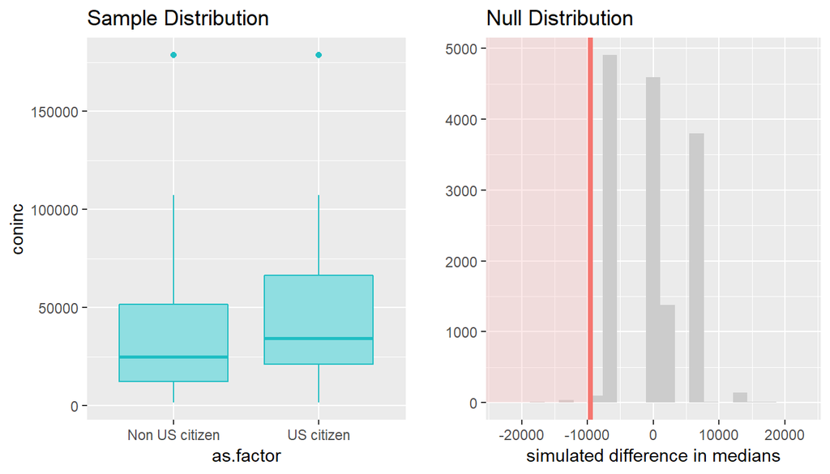

### **INFERENCE 2**

The second hypothesis we test according to the research question is:

**Null Hypothesis (H0): Mean edu years(US) == Mean edu years(non-US)**

**Alternate Hypothesis (HA) : Mean edu years(US) != Mean edu years(non-US)**

Since the inference is conducted on difference of means, the method being used is theoretical. After the inference is run, the confidence interval of the resulting difference in means is also calculated.

```r
# education years equality hypothesis test among US/non US citizens
inference(y = educ, x = as.factor(uscitzn), data =RQ2, statistic = "mean", type = "ht", null = 0, alternative = "twosided", method = "theoretical")
```

```
## Response variable: numerical
## Explanatory variable: categorical (2 levels)
## n_Non US citizen = 122, y_bar_Non US citizen = 11.5082, s_Non US citizen = 5.0783
## n_US citizen = 141, y_bar_US citizen = 13.4823, s_US citizen = 3.9616
## H0: mu_Non US citizen =  mu_US citizen
## HA: mu_Non US citizen != mu_US citizen
## t = -3.4751, df = 121
## p_value = 7e-04
```

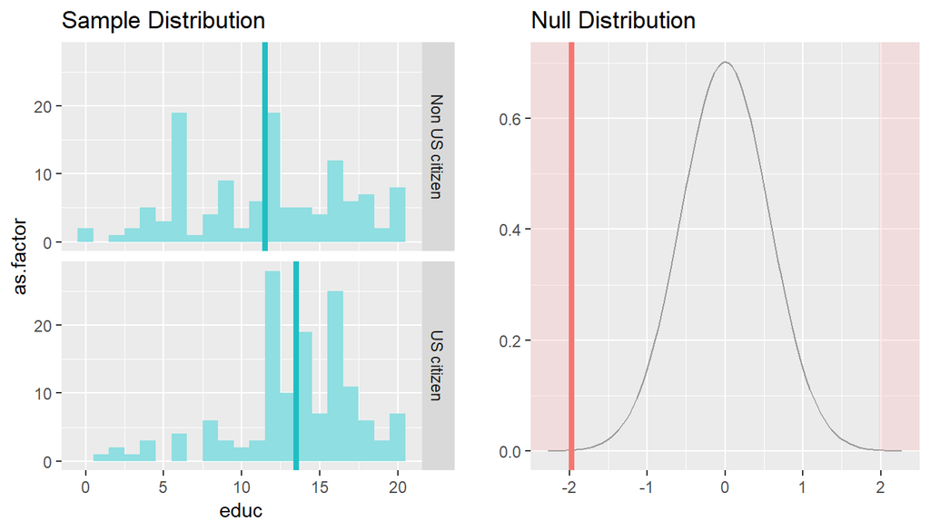

```r
#education years difference confidence intervals
inference(y = educ, x = as.factor(uscitzn), data =RQ2, statistic = "mean", type = "ci", null = 0, alternative = "twosided", method = "theoretical",boot_method="se")
```

```
## Response variable: numerical, Explanatory variable: categorical (2 levels)
## n_Non US citizen = 122, y_bar_Non US citizen = 11.5082, s_Non US citizen = 5.0783
## n_US citizen = 141, y_bar_US citizen = 13.4823, s_US citizen = 3.9616
## 95% CI (Non US citizen - US citizen): (-3.0987 , -0.8494)
```

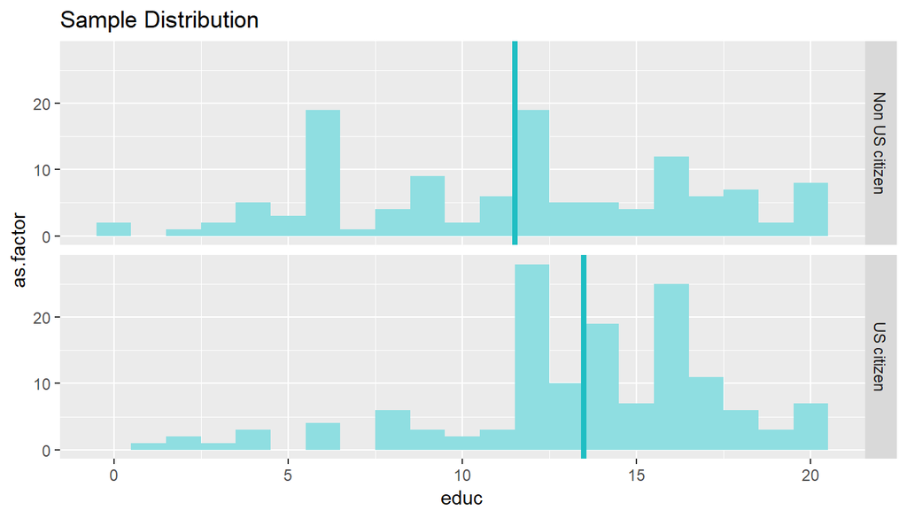

**Null Hypothesis (H0): Mean edu years(US) !> Mean edu years(non-US)**

**Alternate Hypothesis (HA) : Mean edu years(US) > Mean edu years(non-US)**

```r
# discovering higher,lower education years difference among US/non US citizens
inference(y = educ, x = as.factor(uscitzn), data =RQ2, statistic = "mean", type = "ht", null = 0, alternative = "less", method = "theoretical")
```

```
## Response variable: numerical
## Explanatory variable: categorical (2 levels)
## n_Non US citizen = 122, y_bar_Non US citizen = 11.5082, s_Non US citizen = 5.0783
## n_US citizen = 141, y_bar_US citizen = 13.4823, s_US citizen = 3.9616
## H0: mu_Non US citizen =  mu_US citizen
## HA: mu_Non US citizen < mu_US citizen
## t = -3.4751, df = 121
## p_value = 4e-04
```

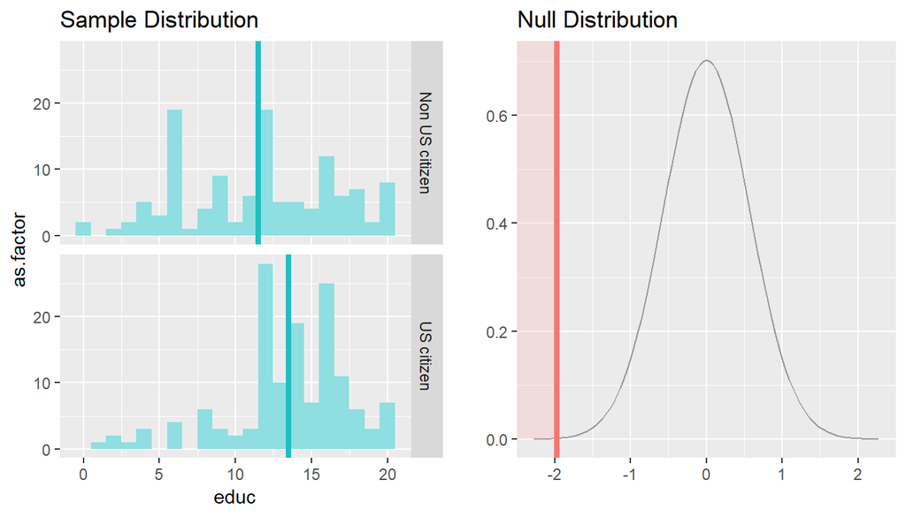

# **CONCLUSION:**

The socio-economic status of US citizens seems to be different from those of non-US citizens when measured in terms of median income, years in education. The density distribution plots give us a graphical idea of the difference which is later confirmed by the inference tests. The inference for greater median income for US citizens is slightly low with p-value:0.011 just sufficient for 5% significance level whereas the inference for greater mean no of years in education for US citizens is highly significant with p-value:0.0004.

However since the study is an observational study by nature, the assosiations between variables in the result(US/non US citizenship to income, education) is only correltional and cannot be considered causal. There might be many unobserved factors such as racial, social bias, inefficient government functioning and public attitude shifts which could have caused the result as seen with this inference.